# R Notebook

# Data intgration(correlation analysis)

### Second we will compare the numeric colomns with the class label,we found that all numeric coulmns are positive corrleated except zip code coulmn so we need to deleate it.

```r
correlation<- cor(CreditCard$Age, CreditCard$Approved)
print(correlation)
```

```
## [1] 0.1640862
```

```r
correlation<- cor(CreditCard$Debt, CreditCard$Approved)
print(correlation)
```

```
## [1] 0.2062937
```

```r
correlation<- cor(CreditCard$YearsEmployed, CreditCard$Approved)
print(correlation)
```

```
## [1] 0.3224754
```

```r
correlation<- cor(CreditCard$CreditScore, CreditCard$Approved)
print(correlation)
```

```
## [1] 0.40641
```

```r
correlation<- cor(CreditCard$Income, CreditCard$Approved)
print(correlation)
```

```
## [1] 0.1756572
```

```r
correlation<- cor(CreditCard$ZipCode, CreditCard$Approved)
print(correlation)
```

```
## [1] -0.09959822
```

```r
CreditCard<-subset(CreditCard,select= -ZipCode)
print(CreditCard)
```

```
## # A tibble: 690 × 15
##    Gender   Age  Debt Married BankCustomer Industry      Ethnicity YearsEmployed
##     <dbl> <dbl> <dbl>   <dbl>        <dbl> <chr>         <chr>             <dbl>
##  1      1  30.8  0          1            1 Industrials   White              1.25
##  2      0  58.7  4.46       1            1 Materials     Black              3.04
##  3      0  24.5  0.5        1            1 Materials     Black              1.5
##  4      1  27.8  1.54       1            1 Industrials   White              3.75
##  5      1  20.2  5.62       1            1 Industrials   White              1.71
##  6      1  32.1  4          1            1 Communicatio… White              2.5
##  7      1  33.2  1.04       1            1 Transport     Black              6.5
##  8      0  22.9 11.6        1            1 InformationT… White              0.04
##  9      1  54.4  0.5        0            0 Financials    Black              3.96
## 10      1  42.5  4.92       0            0 Industrials   White              3.16
## # ℹ 680 more rows
## # ℹ 7 more variables: PriorDefault <dbl>, Employed <dbl>, CreditScore <dbl>,
## #   DriversLicense <dbl>, Citizen <chr>, Income <dbl>, Approved <dbl>
```

# Data cleaning (noisy outliers)

### We relize in Debt coulmn has wide range so it might have outliers

### First we detect and found the outliers from the debt colomn .

```r
#Find outliers

library(outliers)

OutDebt = outlier(CreditCard$Debt, logical =TRUE)
sum(OutDebt)
```

```
## [1] 1
```

```r
Find_outlier = which(OutDebt ==TRUE, arr.ind = TRUE)
OutDebt
```

[output not shown]

[output cut: 43 more lines]

```r
Find_outlier
```

```
## [1] 45
```

## Second we deleted the outliers, and then printed the data set after the changes.

```r
#remove outliers

CreditCard= CreditCard[-Find_outlier,]
print(CreditCard)
```

```
## # A tibble: 689 × 15
##    Gender   Age  Debt Married BankCustomer Industry      Ethnicity YearsEmployed
##     <dbl> <dbl> <dbl>   <dbl>        <dbl> <chr>         <chr>             <dbl>
##  1      1  30.8  0          1            1 Industrials   White              1.25
##  2      0  58.7  4.46       1            1 Materials     Black              3.04
##  3      0  24.5  0.5        1            1 Materials     Black              1.5
##  4      1  27.8  1.54       1            1 Industrials   White              3.75
##  5      1  20.2  5.62       1            1 Industrials   White              1.71
##  6      1  32.1  4          1            1 Communicatio… White              2.5
##  7      1  33.2  1.04       1            1 Transport     Black              6.5
##  8      0  22.9 11.6        1            1 InformationT… White              0.04
##  9      1  54.4  0.5        0            0 Financials    Black              3.96
## 10      1  42.5  4.92       0            0 Industrials   White              3.16
## # ℹ 679 more rows
## # ℹ 7 more variables: PriorDefault <dbl>, Employed <dbl>, CreditScore <dbl>,
## #   DriversLicense <dbl>, Citizen <chr>, Income <dbl>, Approved <dbl>
```

# Data cleaning (noisy outliers)

### As same as Debt ,Income has also huge range.

### Here also we detect and found the outliers from the income colomn. .

```r
#Find outliers for Income

library(outliers)

OutIncome = outlier(CreditCard$Income, logical =TRUE)
sum(OutIncome)
```

```
## [1] 1
```

```r
Find_outlier = which(OutIncome ==TRUE, arr.ind = TRUE)
OutIncome
```

[output not shown]

[output cut: 43 more lines]

```r
Find_outlier
```

```
## [1] 317
```

## Second we deleted the outliers from the income colomn, and then printed the data set after the changes.

```r
#remove outliers

CreditCard= CreditCard[-Find_outlier,]
print(CreditCard)
```

```
## # A tibble: 688 × 15
##    Gender   Age  Debt Married BankCustomer Industry      Ethnicity YearsEmployed
##     <dbl> <dbl> <dbl>   <dbl>        <dbl> <chr>         <chr>             <dbl>
##  1      1  30.8  0          1            1 Industrials   White              1.25
##  2      0  58.7  4.46       1            1 Materials     Black              3.04
##  3      0  24.5  0.5        1            1 Materials     Black              1.5
##  4      1  27.8  1.54       1            1 Industrials   White              3.75
##  5      1  20.2  5.62       1            1 Industrials   White              1.71
##  6      1  32.1  4          1            1 Communicatio… White              2.5
##  7      1  33.2  1.04       1            1 Transport     Black              6.5
##  8      0  22.9 11.6        1            1 InformationT… White              0.04
##  9      1  54.4  0.5        0            0 Financials    Black              3.96
## 10      1  42.5  4.92       0            0 Industrials   White              3.16
## # ℹ 678 more rows
## # ℹ 7 more variables: PriorDefault <dbl>, Employed <dbl>, CreditScore <dbl>,
## #   DriversLicense <dbl>, Citizen <chr>, Income <dbl>, Approved <dbl>
```

# Data transformation (normalization)

### The range of Debt was very wide so we did normalization on Debt to make it in smaller range.

```r
#normlization
CreditCard [, 3:3] = scale(CreditCard [, 3:3])
print(CreditCard)
```

```
## # A tibble: 688 × 15
##    Gender   Age    Debt Married BankCustomer Industry    Ethnicity YearsEmployed
##     <dbl> <dbl>   <dbl>   <dbl>        <dbl> <chr>       <chr>             <dbl>
##  1      1  30.8 -0.967        1            1 Industrials White              1.25
##  2      0  58.7 -0.0493       1            1 Materials   Black              3.04
##  3      0  24.5 -0.864        1            1 Materials   Black              1.5
##  4      1  27.8 -0.650        1            1 Industrials White              3.75
##  5      1  20.2  0.190        1            1 Industrials White              1.71
##  6      1  32.1 -0.144        1            1 Communicat… White              2.5
##  7      1  33.2 -0.753        1            1 Transport   Black              6.5
##  8      0  22.9  1.42         1            1 Informatio… White              0.04
##  9      1  54.4 -0.864        0            0 Financials  Black              3.96
## 10      1  42.5  0.0443       0            0 Industrials White              3.16
## # ℹ 678 more rows
## # ℹ 7 more variables: PriorDefault <dbl>, Employed <dbl>, CreditScore <dbl>,
## #   DriversLicense <dbl>, Citizen <chr>, Income <dbl>, Approved <dbl>
```

# Data transformation (encoding)

```r
#Encoding for income
Income_mean<- mean(CreditCard$Income)
print(Income_mean)
```

```
## [1] 874.9724
```

```r
CreditCard$Income[CreditCard$Income > Income_mean]<- "High"
CreditCard$Income[CreditCard$Income <= Income_mean]<- "low"
print(CreditCard)
```

```
## # A tibble: 688 × 15
##    Gender   Age    Debt Married BankCustomer Industry    Ethnicity YearsEmployed
##     <dbl> <dbl>   <dbl>   <dbl>        <dbl> <chr>       <chr>             <dbl>
##  1      1  30.8 -0.967        1            1 Industrials White              1.25
##  2      0  58.7 -0.0493       1            1 Materials   Black              3.04
##  3      0  24.5 -0.864        1            1 Materials   Black              1.5
##  4      1  27.8 -0.650        1            1 Industrials White              3.75
##  5      1  20.2  0.190        1            1 Industrials White              1.71
##  6      1  32.1 -0.144        1            1 Communicat… White              2.5
##  7      1  33.2 -0.753        1            1 Transport   Black              6.5
##  8      0  22.9  1.42         1            1 Informatio… White              0.04
##  9      1  54.4 -0.864        0            0 Financials  Black              3.96
## 10      1  42.5  0.0443       0            0 Industrials White              3.16
## # ℹ 678 more rows
## # ℹ 7 more variables: PriorDefault <dbl>, Employed <dbl>, CreditScore <dbl>,
## #   DriversLicense <dbl>, Citizen <chr>, Income <chr>, Approved <dbl>
```

# This is our Dataset after pre-processing.

```r
print(CreditCard)
```

```
## # A tibble: 688 × 15
##    Gender   Age    Debt Married BankCustomer Industry    Ethnicity YearsEmployed
##     <dbl> <dbl>   <dbl>   <dbl>        <dbl> <chr>       <chr>             <dbl>
##  1      1  30.8 -0.967        1            1 Industrials White              1.25
##  2      0  58.7 -0.0493       1            1 Materials   Black              3.04
##  3      0  24.5 -0.864        1            1 Materials   Black              1.5
##  4      1  27.8 -0.650        1            1 Industrials White              3.75
##  5      1  20.2  0.190        1            1 Industrials White              1.71
##  6      1  32.1 -0.144        1            1 Communicat… White              2.5
##  7      1  33.2 -0.753        1            1 Transport   Black              6.5
##  8      0  22.9  1.42         1            1 Informatio… White              0.04
##  9      1  54.4 -0.864        0            0 Financials  Black              3.96
## 10      1  42.5  0.0443       0            0 Industrials White              3.16
## # ℹ 678 more rows
## # ℹ 7 more variables: PriorDefault <dbl>, Employed <dbl>, CreditScore <dbl>,
## #   DriversLicense <dbl>, Citizen <chr>, Income <chr>, Approved <dbl>
```

### we split the data into training and testing sets using a 70-30 ratio because it helps preventing overfitting and it provides better real-world performance estimation.

### then we created a formula for the decision tree using the specified class attribute. Then, we built the decision tree model using the `rpart()` function with the “class” method and information gain as the splitting criterion.

### Finally, we visualized the decision tree using the `rpart.plot()` function.

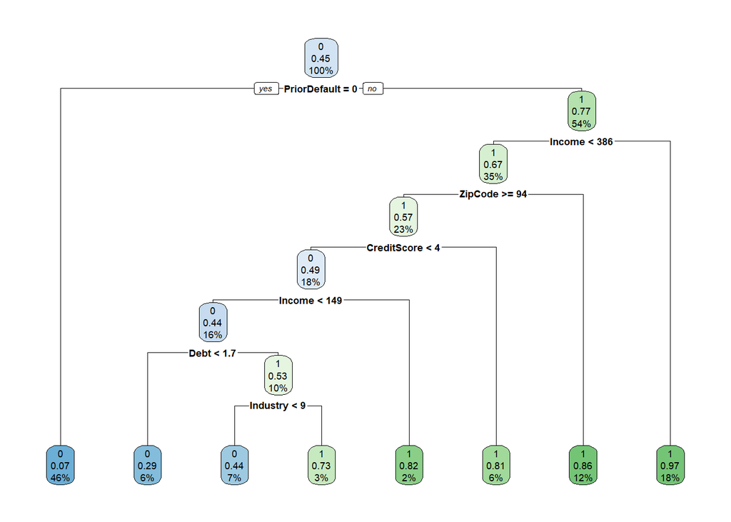

```r
# Load required libraries
library(readxl)
library(dplyr)
library(rpart)
library(rpart.plot)
# Read the dataset
CreditCard <- read_excel("C:/Users/Noni/Desktop/Datamining project/Credit Card Approvals/Dataset/CreditCard.xlsx")

# Specify the class attribute
class_attribute <- "Approved"

# List of character attributes to encode
char_attributes_to_encode <- c("Industry", "Ethnicity", "Citizen")

# Label Encoding
for (char_attribute in char_attributes_to_encode) {
  CreditCard[[char_attribute]] <- as.numeric(factor(CreditCard[[char_attribute]]))
}

# Split the data into training (70%) and testing (30%)
set.seed(123)  # Set seed for reproducibility
sample_index <- sample(1:nrow(CreditCard), 0.7 * nrow(CreditCard))
train_data <- CreditCard[sample_index, ]
test_data <- CreditCard[-sample_index, ]

# Create a formula for the decision tree
formula <- as.formula(paste(class_attribute, " ~ ."))

# Build the decision tree using information gain on the training data
tree_info_gain <- rpart(formula, data = train_data, method = "class", parms = list(split = "information"))

# Visualize the decision tree
rpart.plot(tree_info_gain)
```

```r
# Build the decision tree using information gain on the training data
tree_info_gain <- rpart(formula, data = train_data, method = "class", parms = list(split = "information"))

# Make predictions on the test data
predicted_info_gain <- predict(tree_info_gain, test_data, type = "class")

# Calculate accuracy
accuracy_info_gain <- sum(predicted_info_gain == test_data$Approved) / nrow(test_data)

# Print the accuracy
cat("Accuracy with Information Gain (70-30 Split)", accuracy_info_gain, "\n")
```

```
## Accuracy with Information Gain (70-30 Split) 0.875
```

### we again split the data into training and testing sets using a 70-30 ratio.

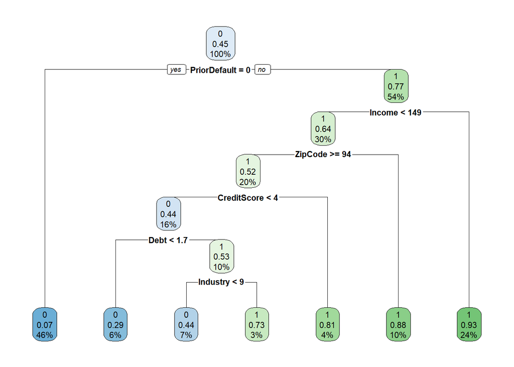

```r
# Load required libraries
library(readxl)
library(dplyr)
library(rpart)
library(rpart.plot)

# Read the dataset
CreditCard <- read_excel("C:/Users/Noni/Desktop/Datamining project/Credit Card Approvals/Dataset/CreditCard.xlsx")
# Specify the class attribute
class_attribute <- "Approved"

# List of character attributes to encode
char_attributes_to_encode <- c("Industry", "Ethnicity", "Citizen")

# Label Encoding
for (char_attribute in char_attributes_to_encode) {
  CreditCard[[char_attribute]] <- as.numeric(factor(CreditCard[[char_attribute]]))
}

# Split the data into training (70%) and testing (30%)
set.seed(123)  # Set seed for reproducibility
sample_index <- sample(1:nrow(CreditCard), 0.7 * nrow(CreditCard))
train_data <- CreditCard[sample_index, ]
test_data <- CreditCard[-sample_index, ]

# Create a formula for the decision tree
formula <- as.formula(paste(class_attribute, " ~ ."))

# Build the decision tree using gain ratio on the training data
tree_gain_ratio <- rpart(formula, data = train_data, method = "class", parms = list(split = "gain"))

# Visualize the decision tree
rpart.plot(tree_gain_ratio)
```

```r
# ... (previous code)

# Build the decision tree using gain ratio on the training data
tree_gain_ratio <- rpart(formula, data = train_data, method = "class", parms = list(split = "gain"))

# Make predictions on the test data
predicted_gain_ratio <- predict(tree_gain_ratio, test_data, type = "class")

# Calculate accuracy
accuracy_gain_ratio <- sum(predicted_gain_ratio == test_data$Approved) / nrow(test_data)

# Print the accuracy
cat("Accuracy with Gain Ratio (70-30 Split):", accuracy_gain_ratio, "\n")
```

```
## Accuracy with Gain Ratio (70-30 Split): 0.875
```

### we again split the data using a 70-30 ratio.

### then created a formula for the decision tree using the specified class attribute. Then, built the decision tree model using the `rpart()` function with the “class” method and Gini index as the splitting criterion.

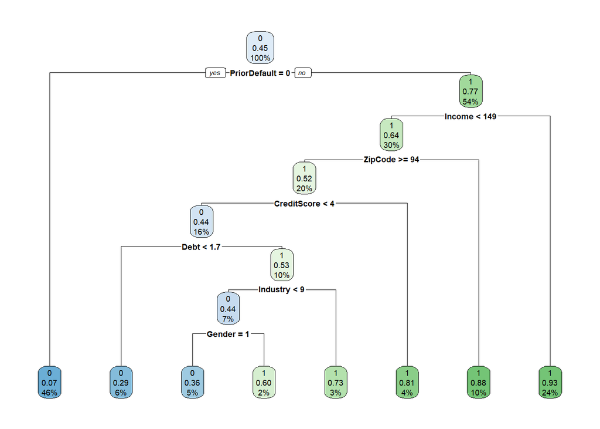

```r
# Load required libraries
library(readxl)
library(dplyr)
library(rpart)
library(rpart.plot)

# Read the dataset
CreditCard <- read_excel("C:/Users/Noni/Desktop/Datamining project/Credit Card Approvals/Dataset/CreditCard.xlsx")

# Specify the class attribute
class_attribute <- "Approved"

# List of character attributes to encode
char_attributes_to_encode <- c("Industry", "Ethnicity", "Citizen")

# Label Encoding
for (char_attribute in char_attributes_to_encode) {
  CreditCard[[char_attribute]] <- as.numeric(factor(CreditCard[[char_attribute]]))
}

# Split the data into training (70%) and testing (30%)
set.seed(123)  # Set seed for reproducibility
sample_index <- sample(1:nrow(CreditCard), 0.7 * nrow(CreditCard))
train_data <- CreditCard[sample_index, ]
test_data <- CreditCard[-sample_index, ]

# Create a formula for the decision tree
formula <- as.formula(paste(class_attribute, " ~ ."))

# Build the decision tree using Gini index on the training data
tree_gini_index <- rpart(formula, data = train_data, method = "class", control = rpart.control(cp = 0.005))

# Visualize the decision tree
rpart.plot(tree_gini_index)
```

```r
# Build the decision tree using Gini index on the training data
tree_gini_index <- rpart(formula, data = train_data, method = "class", control = rpart.control(cp = 0.005))

# Make predictions on the test data
predicted_gini_index <- predict(tree_gini_index, test_data, type = "class")

# Calculate accuracy
accuracy_gini_index <- sum(predicted_gini_index == test_data$Approved) / nrow(test_data)

# Print the accuracy
cat("Accuracy with Gini Index (70-30 Split):", accuracy_gini_index, "\n")
```

```
## Accuracy with Gini Index (70-30 Split): 0.8894231
```

## after doing 3 trees for 70-30 split the best tree with highest accuracy was Gini index

### here we made predictions on the test data

### created the Confusion Matrix

### calculated the Accuracy, Precision, ensitivity (True Positive Rate) , Specificity (True Negative Rate) and printed the results.

### By examining accuracy, precision, sensitivity, and specificity, stakeholders can gain valuable insights into the strengths and weaknesses of the model, aiding in decision-making and potential model refinement.

```r
tree <- rpart(Approved ~ ., data = train_data, method = "class")
# Make predictions on the test data
predicted <- predict(tree, test_data, type = "class")

# Calculate confusion matrix
confusion_matrix <- table(Actual = test_data$Approved, Predicted = predicted)

# Calculate accuracy
accuracy <- sum(diag(confusion_matrix)) / sum(confusion_matrix)

# Calculate precision
precision <- confusion_matrix[2, 2] / sum(confusion_matrix[, 2])

# Calculate sensitivity (true positive rate)
sensitivity <- confusion_matrix[2, 2] / sum(confusion_matrix[2, ])

# Calculate specificity (true negative rate)
specificity <- confusion_matrix[1, 1] / sum(confusion_matrix[1, ])

# Print the results
cat("Accuracy:", accuracy, "\n")
```

```
## Accuracy: 0.875
```

```r
cat("Precision:", precision, "\n")
```

```
## Precision: 0.9113924
```

```r
cat("Sensitivity:", sensitivity, "\n")
```

```
## Sensitivity: 0.7912088
```

```r
cat("Specificity:", specificity, "\n")
```

```
## Specificity: 0.9401709
```

### this time we split the data into training and testing sets using a 80-20 ratio.

### then we created a formula for the decision tree using the specified class attribute. Then, built the decision tree model using the `rpart()` function with the “class” method and information gain as the splitting criterion.

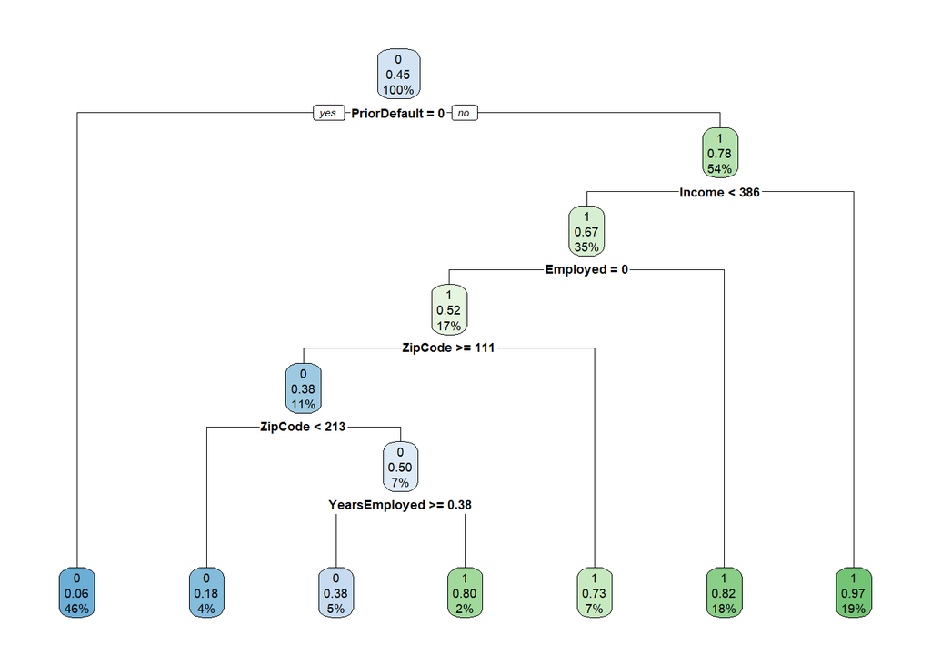

```r
# Load required libraries
library(readxl)
library(dplyr)
library(rpart)
library(rpart.plot)

# Read the dataset
CreditCard <- read_excel("C:/Users/Noni/Desktop/Datamining project/Credit Card Approvals/Dataset/CreditCard.xlsx")

# Specify the class attribute
class_attribute <- "Approved"

# List of character attributes to encode
char_attributes_to_encode <- c("Industry", "Ethnicity", "Citizen")

# Label Encoding
for (char_attribute in char_attributes_to_encode) {
  CreditCard[[char_attribute]] <- as.numeric(factor(CreditCard[[char_attribute]]))
}

# Split the data into training (80%) and testing (20%)
set.seed(123)  # Set seed for reproducibility
sample_index <- sample(1:nrow(CreditCard), 0.8 * nrow(CreditCard))
train_data <- CreditCard[sample_index, ]
test_data <- CreditCard[-sample_index, ]

# Create a formula for the decision tree
formula <- as.formula(paste(class_attribute, " ~ ."))

# Build the decision tree using information gain on the training data
tree_info_gain <- rpart(formula, data = train_data, method = "class", parms = list(split = "information"))

# Visualize the decision tree
rpart.plot(tree_info_gain)
```

```r
# Make predictions on the test data
predicted <- predict(tree_info_gain, test_data, type = "class")

# Calculate accuracy
accuracy <- sum(predicted == test_data$Approved) / nrow(test_data)
cat("Accuracy with Information Gain (80-20 Split)", accuracy, "\n")
```

```
## Accuracy with Information Gain (80-20 Split) 0.8623188
```

### we again split the data into training and testing sets using a 80-20 ratio.

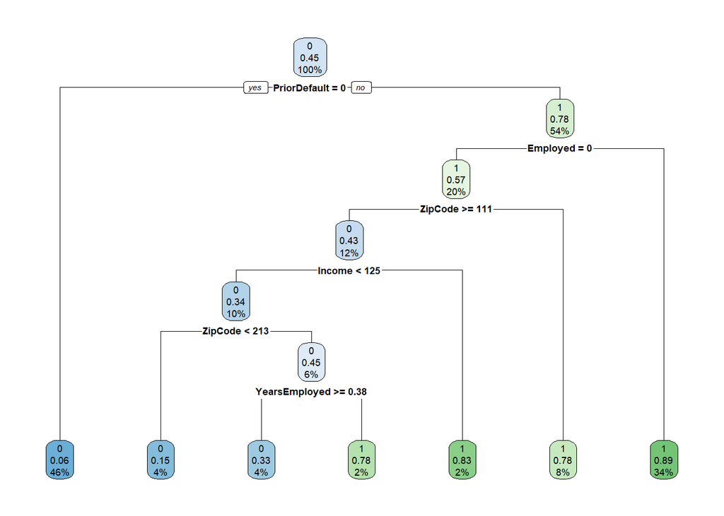

```r
# Load required libraries
library(readxl)
library(dplyr)
library(rpart)
library(rpart.plot)

# Read the dataset
CreditCard <- read_excel("C:/Users/Noni/Desktop/Datamining project/Credit Card Approvals/Dataset/CreditCard.xlsx")

# Specify the class attribute
class_attribute <- "Approved"

# List of character attributes to encode
char_attributes_to_encode <- c("Industry", "Ethnicity", "Citizen")

# Label Encoding
for (char_attribute in char_attributes_to_encode) {
  CreditCard[[char_attribute]] <- as.numeric(factor(CreditCard[[char_attribute]]))
}

# Split the data into training (80%) and testing (20%)
set.seed(123)  # Set seed for reproducibility
sample_index <- sample(1:nrow(CreditCard), 0.8 * nrow(CreditCard))
train_data <- CreditCard[sample_index, ]
test_data <- CreditCard[-sample_index, ]

# Create a formula for the decision tree
formula <- as.formula(paste(class_attribute, " ~ ."))

# Build the decision tree using gain ratio on the training data
tree_gain_ratio <- rpart(formula, data = train_data, method = "class", parms = list(split = "gain"))

# Visualize the decision tree
rpart.plot(tree_gain_ratio)
```

```r
# Make predictions on the test data
predicted <- predict(tree_gain_ratio, test_data, type = "class")

# Calculate accuracy
accuracy <- sum(predicted == test_data$Approved) / nrow(test_data)
cat("Accuracy with Gain Ratio (80-20 Split):", accuracy, "\n")
```

```
## Accuracy with Gain Ratio (80-20 Split): 0.8768116
```

### we again split the data using a 80-20 ratio.

### then created a formula for the decision tree using the specified class attribute. Then, built the decision tree model using the `rpart()` function with the “class” method and Gini index as the splitting criterion.

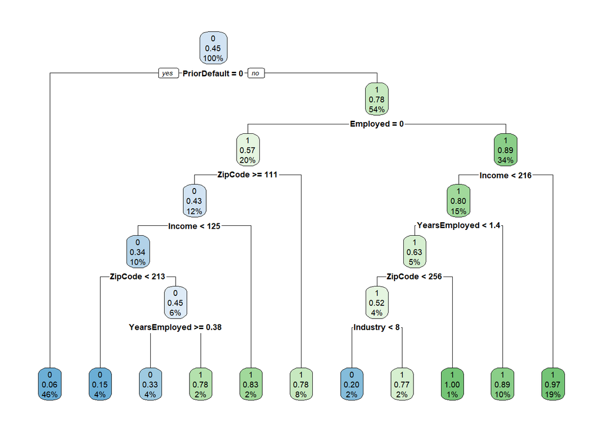

```r
# Load required libraries
library(readxl)
library(dplyr)
library(rpart)
library(rpart.plot)

# Read the dataset
CreditCard <- read_excel("C:/Users/Noni/Desktop/Datamining project/Credit Card Approvals/Dataset/CreditCard.xlsx")

# Specify the class attribute
class_attribute <- "Approved"

# List of character attributes to encode
char_attributes_to_encode <- c("Industry", "Ethnicity", "Citizen")

# Label Encoding
for (char_attribute in char_attributes_to_encode) {
  CreditCard[[char_attribute]] <- as.numeric(factor(CreditCard[[char_attribute]]))
}

# Split the data into training (80%) and testing (20%)
set.seed(123)  # Set seed for reproducibility
sample_index <- sample(1:nrow(CreditCard), 0.8 * nrow(CreditCard))
train_data <- CreditCard[sample_index, ]
test_data <- CreditCard[-sample_index, ]

# Create a formula for the decision tree
formula <- as.formula(paste(class_attribute, " ~ ."))

# Build the decision tree using Gini index on the training data
tree_gini_index <- rpart(formula, data = train_data, method = "class", control = rpart.control(cp = 0.005))

# Visualize the decision tree
rpart.plot(tree_gini_index)
```

```r
# Make predictions on the test data
predicted <- predict(tree_gini_index, test_data, type = "class")

# Calculate accuracy
accuracy <- sum(predicted == test_data$Approved) / nrow(test_data)
cat("Accuracy with Gini Index (80-20 Split):", accuracy, "\n")
```

```
## Accuracy with Gini Index (80-20 Split): 0.8623188
```

## after doing 3 trees for 80-20 split the best tree with highest accuracy was Gain ratio

### we made predictions on the test data

### created the Confusion Matrix

### calculated the Accuracy, Precision, ensitivity (True Positive Rate) , Specificity (True Negative Rate) and printed the results.

```r
tree <- rpart(Approved ~ ., data = train_data, method = "class")
# Make predictions on the test data
predicted <- predict(tree, test_data, type = "class")

# Calculate confusion matrix
confusion_matrix <- table(Actual = test_data$Approved, Predicted = predicted)

# Calculate accuracy
accuracy <- sum(diag(confusion_matrix)) / sum(confusion_matrix)

# Calculate precision
precision <- confusion_matrix[2, 2] / sum(confusion_matrix[, 2])

# Calculate sensitivity (true positive rate)
sensitivity <- confusion_matrix[2, 2] / sum(confusion_matrix[2, ])

# Calculate specificity (true negative rate)
specificity <- confusion_matrix[1, 1] / sum(confusion_matrix[1, ])

# Print the results
cat("Accuracy:", accuracy, "\n")
```

```
## Accuracy: 0.8768116
```

```r
cat("Precision:", precision, "\n")
```

```
## Precision: 0.9056604
```

```r
cat("Sensitivity:", sensitivity, "\n")
```

```
## Sensitivity: 0.8
```

```r
cat("Specificity:", specificity, "\n")
```

```
## Specificity: 0.9358974
```

### and this time we split the data into training and testing sets using a 60-40 ratio.

### then we created a formula for the decision tree using the specified class attribute. Then, built the decision tree model using the `rpart()` function with the “class” method and information gain as the splitting criterion.

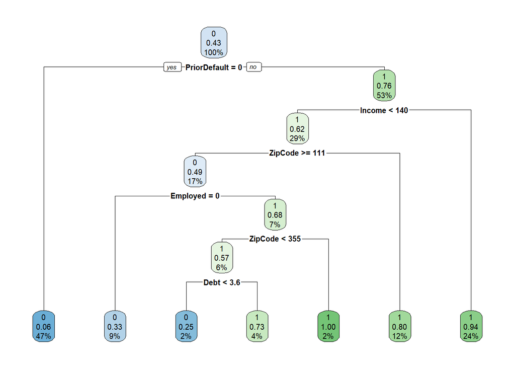

```r
# Load required libraries
library(readxl)
library(dplyr)
library(rpart)
library(rpart.plot)

# Read the dataset
CreditCard <- read_excel("C:/Users/Noni/Desktop/Datamining project/Credit Card Approvals/Dataset/CreditCard.xlsx")

# Specify the class attribute
class_attribute <- "Approved"

# List of character attributes to encode
char_attributes_to_encode <- c("Industry", "Ethnicity", "Citizen")

# Label Encoding
for (char_attribute in char_attributes_to_encode) {
  CreditCard[[char_attribute]] <- as.numeric(factor(CreditCard[[char_attribute]]))
}

# Split the data into training (60%) and testing (40%)
set.seed(123)  # Set seed for reproducibility
sample_index <- sample(1:nrow(CreditCard), 0.6 * nrow(CreditCard))
train_data <- CreditCard[sample_index, ]
test_data <- CreditCard[-sample_index, ]

# Create a formula for the decision tree
formula <- as.formula(paste(class_attribute, " ~ ."))

# Build the decision tree using information gain on the training data
tree_info_gain <- rpart(formula, data = train_data, method = "class", parms = list(split = "information"))

# Visualize the decision tree
rpart.plot(tree_info_gain)
```

```r
# Make predictions on the test data
predicted <- predict(tree_info_gain, test_data, type = "class")

# Calculate accuracy
accuracy <- sum(predicted == test_data$Approved) / nrow(test_data)
cat("Accuracy with Information Gain (60-40 Split):", accuracy, "\n")
```

```
## Accuracy with Information Gain (60-40 Split): 0.8695652
```

### we again split the data into training and testing sets using a 60-40 ratio.

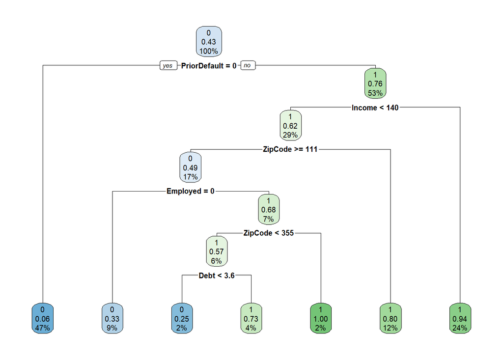

```r
# Load required libraries
library(readxl)
library(dplyr)
library(rpart)
library(rpart.plot)

# Read the dataset
CreditCard <- read_excel("C:/Users/Noni/Desktop/Datamining project/Credit Card Approvals/Dataset/CreditCard.xlsx")

# Specify the class attribute
class_attribute <- "Approved"

# List of character attributes to encode
char_attributes_to_encode <- c("Industry", "Ethnicity", "Citizen")

# Label Encoding
for (char_attribute in char_attributes_to_encode) {
  CreditCard[[char_attribute]] <- as.numeric(factor(CreditCard[[char_attribute]]))
}

# Split the data into training (60%) and testing (40%)
set.seed(123)  # Set seed for reproducibility
sample_index <- sample(1:nrow(CreditCard), 0.6 * nrow(CreditCard))
train_data <- CreditCard[sample_index, ]
test_data <- CreditCard[-sample_index, ]

# Create a formula for the decision tree
formula <- as.formula(paste(class_attribute, " ~ ."))

# Build the decision tree using gain ratio on the training data
tree_gain_ratio <- rpart(formula, data = train_data, method = "class", parms = list(split = "gain"))

# Visualize the decision tree
rpart.plot(tree_gain_ratio)
```

```r
# Make predictions on the test data
predicted <- predict(tree_gain_ratio, test_data, type = "class")

# Calculate accuracy
accuracy <- sum(predicted == test_data$Approved) / nrow(test_data)
cat("Accuracy with Gain Ratio (60-40 Split):", accuracy, "\n")
```

```
## Accuracy with Gain Ratio (60-40 Split): 0.8695652
```

### we again again split the data using a 60-40 ratio.

### then created a formula for the decision tree using the specified class attribute. Then, built the decision tree model using the `rpart()` function with the “class” method and Gini index as the splitting criterion.

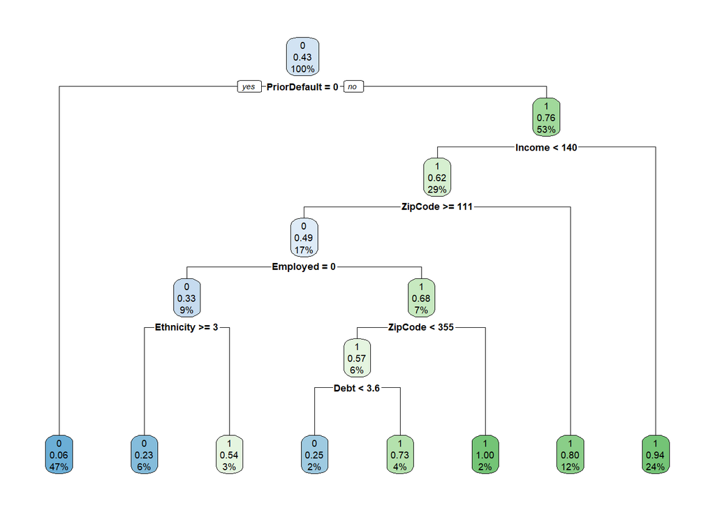

```r
# Load required libraries
library(readxl)
library(dplyr)
library(rpart)
library(rpart.plot)

# Read the dataset
CreditCard <- read_excel("C:/Users/Noni/Desktop/Datamining project/Credit Card Approvals/Dataset/CreditCard.xlsx")

# Specify the class attribute
class_attribute <- "Approved"

# List of character attributes to encode
char_attributes_to_encode <- c("Industry", "Ethnicity", "Citizen")

# Label Encoding
for (char_attribute in char_attributes_to_encode) {
  CreditCard[[char_attribute]] <- as.numeric(factor(CreditCard[[char_attribute]]))
}

# Split the data into training (60%) and testing (40%)
set.seed(123)  # Set seed for reproducibility
sample_index <- sample(1:nrow(CreditCard), 0.6 * nrow(CreditCard))
train_data <- CreditCard[sample_index, ]
test_data <- CreditCard[-sample_index, ]

# Create a formula for the decision tree
formula <- as.formula(paste(class_attribute, " ~ ."))

# Build the decision tree using Gini index on the training data
tree_gini_index <- rpart(formula, data = train_data, method = "class", control = rpart.control(cp = 0.005))

# Visualize the decision tree
rpart.plot(tree_gini_index)
```

```r
# Make predictions on the test data
predicted <- predict(tree_gini_index, test_data, type = "class")

# Calculate accuracy
accuracy <- sum(predicted == test_data$Approved) / nrow(test_data)
cat("Accuracy with Gini Index (60-40 Split):", accuracy, "\n")
```

```
## Accuracy with Gini Index (60-40 Split): 0.8586957
```

## after doing 3 trees for 60-40 split the best tree with highest accuracy was information gain and Gain ratio

### here we made predictions on the test data

### created the Confusion Matrix

### calculated the Accuracy, Precision, ensitivity (True Positive Rate) , Specificity (True Negative Rate) and printed the results.

```r
tree <- rpart(Approved ~ ., data = train_data, method = "class")
# Make predictions on the test data
predicted <- predict(tree, test_data, type = "class")

# Calculate confusion matrix
confusion_matrix <- table(Actual = test_data$Approved, Predicted = predicted)

# Calculate accuracy
accuracy <- sum(diag(confusion_matrix)) / sum(confusion_matrix)

# Calculate precision
precision <- confusion_matrix[2, 2] / sum(confusion_matrix[, 2])

# Calculate sensitivity (true positive rate)
sensitivity <- confusion_matrix[2, 2] / sum(confusion_matrix[2, ])

# Calculate specificity (true negative rate)
specificity <- confusion_matrix[1, 1] / sum(confusion_matrix[1, ])

# Print the results
cat("Accuracy:", accuracy, "\n")
```

```
## Accuracy: 0.8695652
```

```r
cat("Precision:", precision, "\n")
```

```
## Precision: 0.9174312
```

```r
cat("Sensitivity:", sensitivity, "\n")
```

```
## Sensitivity: 0.7874016
```

```r
cat("Specificity:", specificity, "\n")
```

```
## Specificity: 0.9395973
```

### to determine the appropriate number of clusters for our data, we need to observe the elbow point.

### we Selected the Numeric Attributes for Clustering

### then we specified The range of K values to be tested in the elbow method

### we initialized An empty vector (wcss_values) to store the Within-Cluster Sum of Squares (WCSS) values for each tested K.

### then calculated the WCSS for Each K Value.

### then created a data frame (elbow_data) to store the K values and their corresponding WCSS values.

### finally we Ploted K versus WCSS Using ggplot2

```r
# Load required libraries
library(readxl)
library(cluster)
```

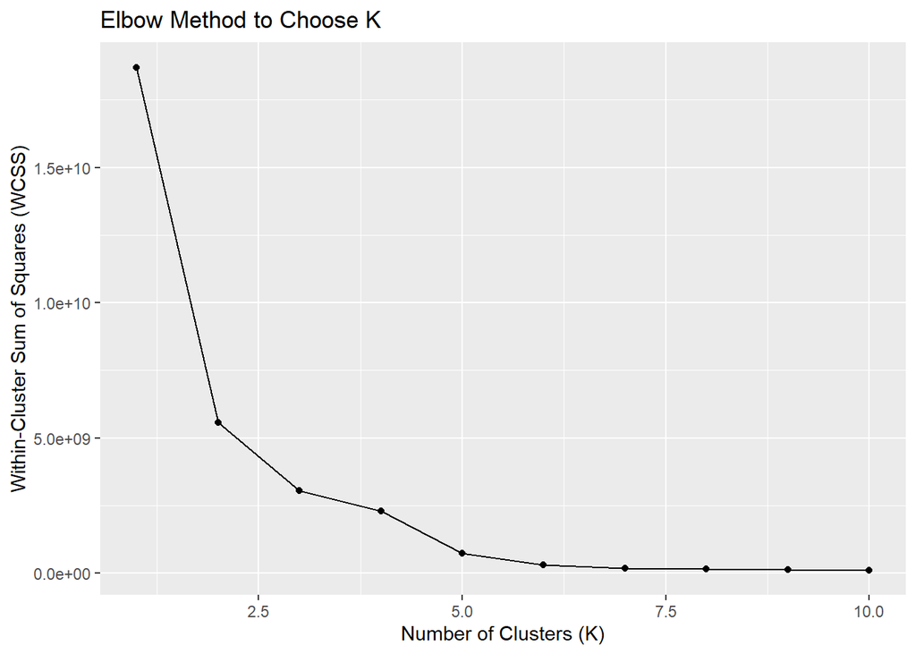

```r
library(ggplot2)

# Read the dataset
CreditCard <- read_excel("C:/Users/Noni/Desktop/Datamining project/Credit Card Approvals/Dataset/CreditCard.xlsx")

# Select the numeric attributes for clustering (exclude non-numeric or irrelevant columns)
numeric_attributes <- CreditCard[, c("Age", "YearsEmployed", "Debt", "CreditScore", "Income")]

# Specify the range of K values you want to test
k_values <- 1:10  # You can adjust the range

# Initialize a vector to store the WCSS values
wcss_values <- vector()

# Calculate WCSS for each K value
for (k in k_values) {
  kmeans_result <- kmeans(numeric_attributes, centers = k)
  wcss_values <- c(wcss_values, kmeans_result$tot.withinss)
}

# Create a data frame to plot K versus WCSS
elbow_data <- data.frame(K = k_values, WCSS = wcss_values)

# Plot K versus WCSS
ggplot(elbow_data, aes(x = K, y = WCSS)) +
  geom_line() +
  geom_point() +
  labs(x = "Number of Clusters (K)", y = "Within-Cluster Sum of Squares (WCSS)") +
  ggtitle("Elbow Method to Choose K")
```

```r
# Load required libraries
library(dplyr)
library(factoextra)
```

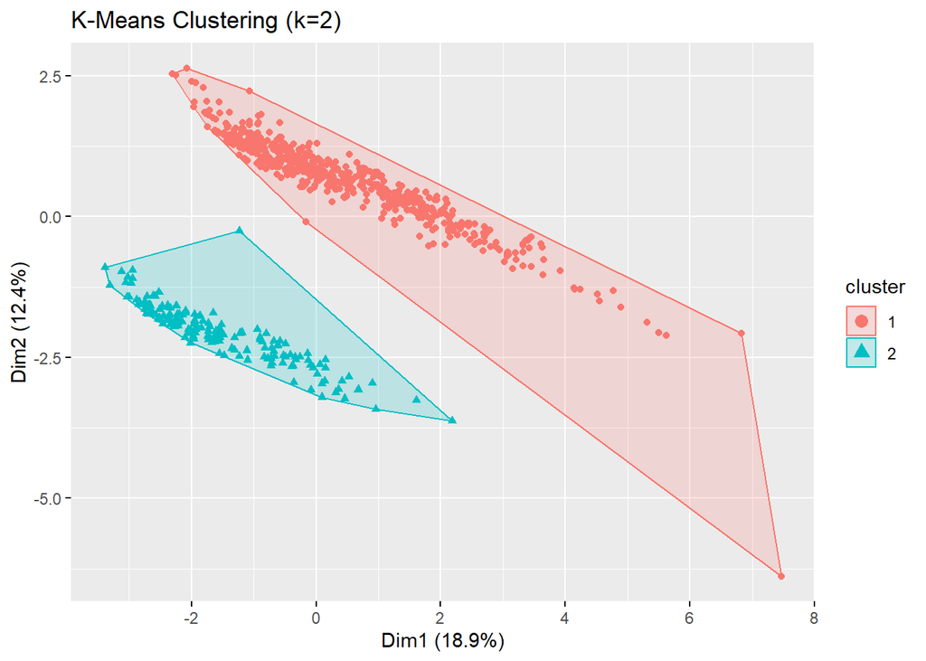

```r
# Encode categorical variables (Industry, Ethnicity, Citizen)
CreditCard_encoded <- CreditCard %>%
  mutate(
    Industry = as.numeric(factor(Industry)),
    Ethnicity = as.numeric(factor(Ethnicity)),
    Citizen = as.numeric(factor(Citizen))
  )

# Extract the features for clustering (excluding 'Approved' column)
features <- CreditCard_encoded %>%
  select(-Approved)

# Scale the features
scaled_data <- scale(features)

# Perform k-means clustering with k=2
kmeans_result <- kmeans(scaled_data, centers = 2, nstart = 25)

# Visualize the clusters
fviz_cluster(kmeans_result, data = scaled_data, geom = "point",
             stand = FALSE, # Don't standardize the variables
             main = "K-Means Clustering (k=2)")
```

### the following code will calculate the Bcubed precision and recall, witch will assess the quality of our clustering result by comparing it to known ground truth labels.

```r
cluster_assignments <- kmeans_result$cluster
ground_truth_labels <- CreditCard$Approved
data <- data.frame(cluster = cluster_assignments, label = ground_truth_labels)

# Function to calculate BCubed precision and recall
calculate_bcubed_metrics <- function(data) {
  n <- nrow(data)
  precision_sum <- 0
  recall_sum <- 0

  for (i in 1:n) {
    cluster <- data$cluster[i]
    label <- data$label[i]

    # Count the number of items from the same category within the same cluster
    same_category_same_cluster <- sum(data$label[data$cluster == cluster] == label)

    # Count the total number of items in the same cluster
    total_same_cluster <- sum(data$cluster == cluster)

    # Count the total number of items with the same category
    total_same_category <- sum(data$label == label)

    # Calculate precision and recall for the current item and add them to the sums
    precision_sum <- precision_sum + same_category_same_cluster / total_same_cluster
    recall_sum <- recall_sum + same_category_same_cluster / total_same_category
  }

  # Calculate average precision and recall
  precision <- precision_sum / n
  recall <- recall_sum / n

  return(list(precision = precision, recall = recall))
}

# Calculate BCubed precision and recall
metrics <- calculate_bcubed_metrics(data)

# Extract precision and recall from the metrics
precision <- metrics$precision
recall <- metrics$recall

# Print the results
cat("BCubed Precision:", precision, "\n")
```

```
## BCubed Precision: 0.5237031
```

```r
cat("BCubed Recall:", recall, "\n")
```

```
## BCubed Recall: 0.6520324
```

### the following code performs k-means clustering on our dataset after encoding and scaling the features. It also calculates the Silhouette Score and the Total Within-Cluster Sum of Squares (WSS) for evaluating the clustering results.

```r
# Load required libraries
library(cluster)
library(factoextra)
library(dplyr)


# Encoding and scaling
CreditCard_encoded <- CreditCard %>%
  mutate(
    Industry = as.numeric(factor(Industry)),
    Ethnicity = as.numeric(factor(Ethnicity)),
    Citizen = as.numeric(factor(Citizen))
  )

# Remove the class label 'Approved'
CreditCard_scaled <- CreditCard_encoded %>%
  select(-Approved) %>%
  scale()

# Specify the number of clusters (k)
k <- 2

# Perform k-means clustering with k clusters
kmeans_result <- kmeans(CreditCard_scaled, centers = k, nstart = 25)

# Silhouette Score
silhouette_score <- silhouette(kmeans_result$cluster, dist(CreditCard_scaled))
cat("Silhouette Score for k =", k, ":", mean(silhouette_score[, "sil_width"]), "\n")
```

```
## Silhouette Score for k = 2 : 0.1765312
```

```r
# Total Within-Cluster Sum of Squares (WSS)
wss <- kmeans_result$tot.withinss
cat("Total Within-Cluster Sum of Squares (WSS) for k =", k, ":", wss, "\n")
```

```
## Total Within-Cluster Sum of Squares (WSS) for k = 2 : 8900.655
```

### the following code performs k-means clustering our dataset with a specified number of clusters (k = 2). It then calculates silhouette information, including the average silhouette width for each cluster, and visualizes the silhouette plot using the factoextra library.

```
##   cluster size ave.sil.width
## 1       1  527          0.15
## 2       2  163          0.27
```

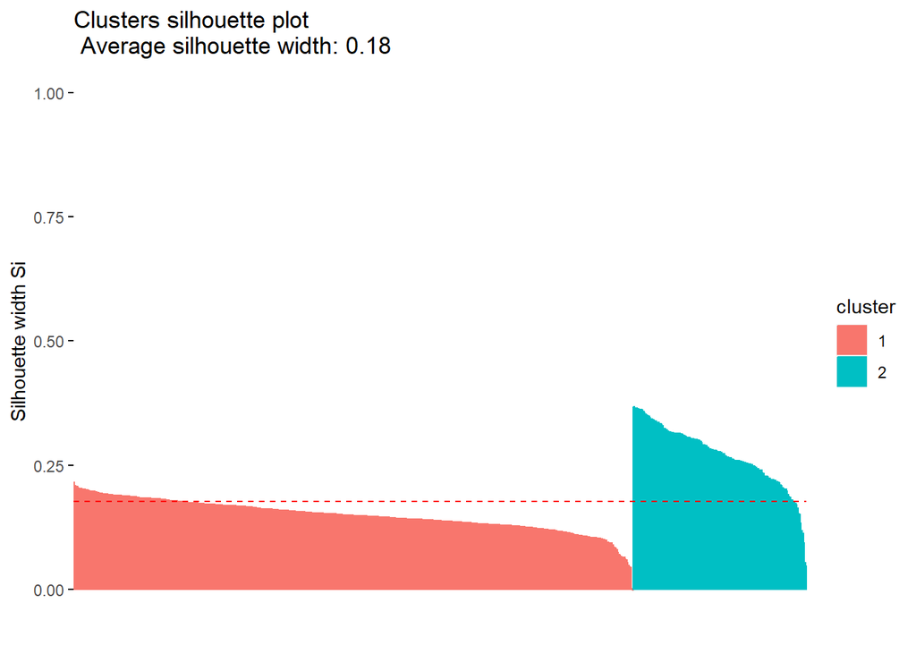

```r
# Load required libraries
library(cluster)
library(factoextra)
library(dplyr)
library(fpc)  # Add this line to load the fpc package

# Assume 'CreditCard' is your dataset

# Encoding and scaling
CreditCard_encoded <- CreditCard %>%
  mutate(
    Industry = as.numeric(factor(Industry)),
    Ethnicity = as.numeric(factor(Ethnicity)),
    Citizen = as.numeric(factor(Citizen))
  )

# Remove the class label 'Approved'
CreditCard_scaled <- CreditCard_encoded %>%
  select(-Approved) %>%
  scale()

# Specify the number of clusters (k)
k <- 2

# Perform k-means clustering with k clusters
kmeans_result <- kmeans(CreditCard_scaled, centers = k, nstart = 25)

# Calculate silhouette information
sil_info <- silhouette(kmeans_result$cluster, dist(CreditCard_scaled))

# Calculate average silhouette width for each cluster
avg_sil_width <- cluster.stats(dist(CreditCard_scaled), kmeans_result$cluster)$avg.silwidth

# Visualize silhouette plot
fviz_silhouette(sil_info)
```

```r
# Print average silhouette width for each cluster
cat("Average Silhouette Width for each cluster:\n")
```

```
## Average Silhouette Width for each cluster:
```

```r
cat(paste("Cluster", 1:k, ": ", avg_sil_width, "\n"))
```

```
## Cluster 1 :  0.176531154979287
##  Cluster 2 :  0.176531154979287
```

### the following code performs k-means clustering on our dataset with a specified number of clusters (k = 3). It then visualizes the clusters using the factoextra library.

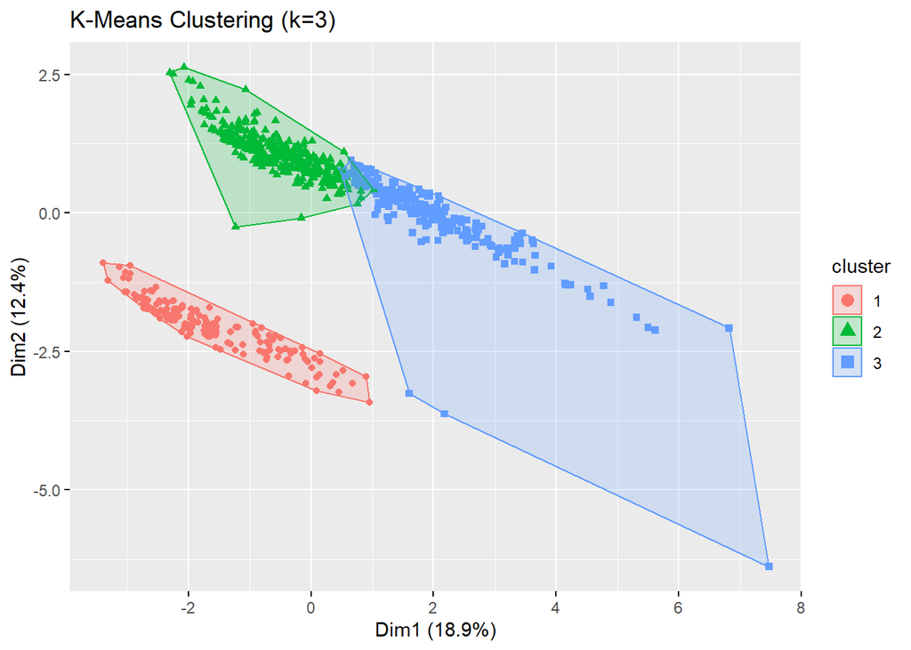

```r
# Load required libraries
library(dplyr)
library(factoextra)


# Encode categorical variables (Industry, Ethnicity, Citizen)
CreditCard_encoded <- CreditCard %>%
  mutate(
    Industry = as.numeric(factor(Industry)),
    Ethnicity = as.numeric(factor(Ethnicity)),
    Citizen = as.numeric(factor(Citizen))
  )

# Extract the features for clustering (excluding 'Approved' column)
features <- CreditCard_encoded %>%
  select(-Approved)

# Scale the features
scaled_data <- scale(features)

# Perform k-means clustering with k=3
kmeans_result <- kmeans(scaled_data, centers = 3, nstart = 25)

# Visualize the clusters
fviz_cluster(kmeans_result, data = scaled_data, geom = "point",
             stand = FALSE, # Don't standardize the variables
             main = "K-Means Clustering (k=3)")
```

```r
 cluster_assignments <- kmeans_result$cluster
ground_truth_labels <- CreditCard$Approved
data <- data.frame(cluster = cluster_assignments, label = ground_truth_labels)

# Function to calculate BCubed precision and recall
calculate_bcubed_metrics <- function(data) {
  n <- nrow(data)
  precision_sum <- 0
  recall_sum <- 0

  for (i in 1:n) {
    cluster <- data$cluster[i]
    label <- data$label[i]

    # Count the number of items from the same category within the same cluster
    same_category_same_cluster <- sum(data$label[data$cluster == cluster] == label)

    # Count the total number of items in the same cluster
    total_same_cluster <- sum(data$cluster == cluster)

    # Count the total number of items with the same category
    total_same_category <- sum(data$label == label)

    # Calculate precision and recall for the current item and add them to the sums
    precision_sum <- precision_sum + same_category_same_cluster / total_same_cluster
    recall_sum <- recall_sum + same_category_same_cluster / total_same_category
  }

  # Calculate average precision and recall
  precision <- precision_sum / n
  recall <- recall_sum / n

  return(list(precision = precision, recall = recall))
}

# Calculate BCubed precision and recall
metrics <- calculate_bcubed_metrics(data)

# Extract precision and recall from the metrics
precision <- metrics$precision
recall <- metrics$recall

# Print the results
cat("BCubed Precision:", precision, "\n")
```

```
## BCubed Precision: 0.6826586
```

```r
cat("BCubed Recall:", recall, "\n")
```

```
## BCubed Recall: 0.4799486
```

```r
# Load required libraries
library(cluster)
library(factoextra)
library(dplyr)

# Encoding and scaling
CreditCard_encoded <- CreditCard %>%
  mutate(
    Industry = as.numeric(factor(Industry)),
    Ethnicity = as.numeric(factor(Ethnicity)),
    Citizen = as.numeric(factor(Citizen))
  )

# Remove the class label 'Approved'
CreditCard_scaled <- CreditCard_encoded %>%
  select(-Approved) %>%
  scale()

# Specify the number of clusters (k)
k <- 3

# Perform k-means clustering with k clusters
kmeans_result <- kmeans(CreditCard_scaled, centers = k, nstart = 25)

# Silhouette Score
silhouette_score <- silhouette(kmeans_result$cluster, dist(CreditCard_scaled))
cat("Silhouette Score for k =", k, ":", mean(silhouette_score[, "sil_width"]), "\n")
```

```
## Silhouette Score for k = 3 : 0.1694531
```

```r
# Total Within-Cluster Sum of Squares (WSS)
wss <- kmeans_result$tot.withinss
cat("Total Within-Cluster Sum of Squares (WSS) for k =", k, ":", wss, "\n")
```

```
## Total Within-Cluster Sum of Squares (WSS) for k = 3 : 7844.349
```

### the following code performs k-means clustering on our dataset with a specified number of clusters (k = 3). It then calculates silhouette information, including the average silhouette width for each cluster, and visualizes the silhouette plot using the factoextra library.

```
##   cluster size ave.sil.width
## 1       1  214          0.10
## 2       2  316          0.19
## 3       3  160          0.24
```

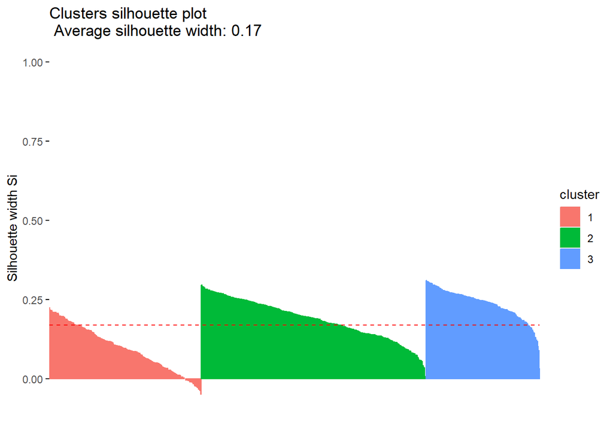

```r
# Load required libraries
library(cluster)
library(factoextra)
library(dplyr)


# Encoding and scaling
CreditCard_encoded <- CreditCard %>%
  mutate(
    Industry = as.numeric(factor(Industry)),
    Ethnicity = as.numeric(factor(Ethnicity)),
    Citizen = as.numeric(factor(Citizen))
  )

# Remove the class label 'Approved'
CreditCard_scaled <- CreditCard_encoded %>%
  select(-Approved) %>%
  scale()

# Specify the number of clusters (k)
k <- 3

# Perform k-means clustering with k clusters
kmeans_result <- kmeans(CreditCard_scaled, centers = k, nstart = 25)

# Calculate silhouette information
sil_info <- silhouette(kmeans_result$cluster, dist(CreditCard_scaled))

# Calculate average silhouette width for each cluster
avg_sil_width <- cluster.stats(dist(CreditCard_scaled), kmeans_result$cluster)$avg.silwidth

# Visualize silhouette plot
fviz_silhouette(sil_info)
```

```r
# Print average silhouette width for each cluster
cat("Average Silhouette Width for each cluster:\n")
```

```
## Average Silhouette Width for each cluster:
```

```r
cat(paste("Cluster", 1:k, ": ", avg_sil_width, "\n"))
```

```
## Cluster 1 :  0.16945306847269
##  Cluster 2 :  0.16945306847269
##  Cluster 3 :  0.16945306847269
```

### code performs k-means clustering on our dataset with a specified number of clusters (k = 4). It then visualizes the clusters using the factoextra library

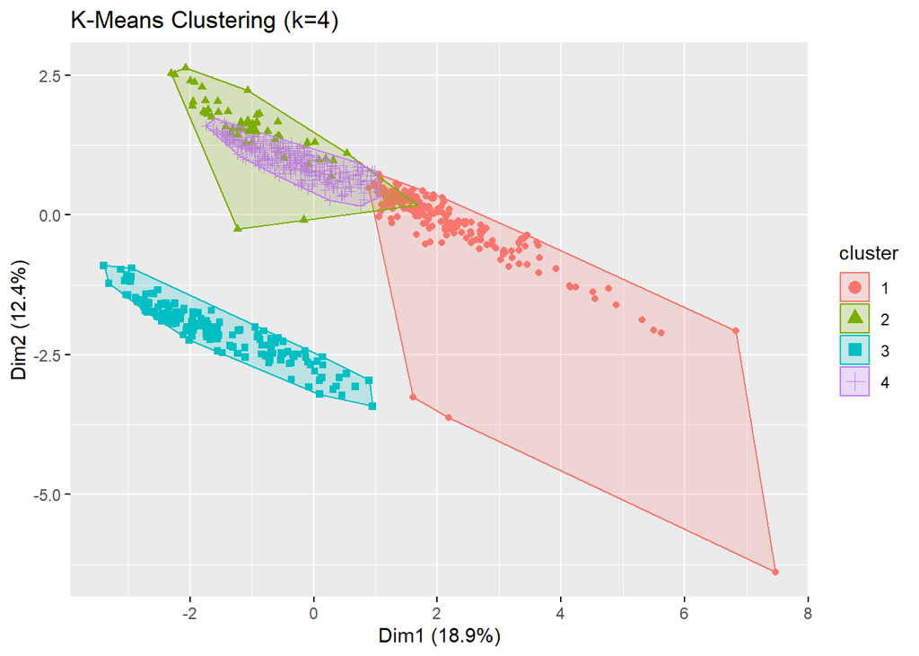

```r
# Load required libraries
library(dplyr)
library(factoextra)


# Encode categorical variables (Industry, Ethnicity, Citizen)
CreditCard_encoded <- CreditCard %>%
  mutate(
    Industry = as.numeric(factor(Industry)),
    Ethnicity = as.numeric(factor(Ethnicity)),
    Citizen = as.numeric(factor(Citizen))
  )

# Extract the features for clustering (excluding 'Approved' column)
features <- CreditCard_encoded %>%
  select(-Approved)

# Scale the features
scaled_data <- scale(features)

# Perform k-means clustering with k=2
kmeans_result <- kmeans(scaled_data, centers = 4, nstart = 25)

# Visualize the clusters
fviz_cluster(kmeans_result, data = scaled_data, geom = "point",
             stand = FALSE, # Don't standardize the variables
             main = "K-Means Clustering (k=4)")
```

## the following code calculates BCubed precision and recall for evaluating the quality of our clustering result compared to ground truth labels.

```r
cluster_assignments <- kmeans_result$cluster
ground_truth_labels <- CreditCard$Approved
data <- data.frame(cluster = cluster_assignments, label = ground_truth_labels)

# Function to calculate BCubed precision and recall
calculate_bcubed_metrics <- function(data) {
  n <- nrow(data)
  precision_sum <- 0
  recall_sum <- 0

  for (i in 1:n) {
    cluster <- data$cluster[i]
    label <- data$label[i]

    # Count the number of items from the same category within the same cluster
    same_category_same_cluster <- sum(data$label[data$cluster == cluster] == label)

    # Count the total number of items in the same cluster
    total_same_cluster <- sum(data$cluster == cluster)

    # Count the total number of items with the same category
    total_same_category <- sum(data$label == label)

    # Calculate precision and recall for the current item and add them to the sums
    precision_sum <- precision_sum + same_category_same_cluster / total_same_cluster
    recall_sum <- recall_sum + same_category_same_cluster / total_same_category
  }

  # Calculate average precision and recall
  precision <- precision_sum / n
  recall <- recall_sum / n

  return(list(precision = precision, recall = recall))
}

# Calculate BCubed precision and recall
metrics <- calculate_bcubed_metrics(data)

# Extract precision and recall from the metrics
precision <- metrics$precision
recall <- metrics$recall

# Print the results
cat("BCubed Precision:", precision, "\n")
```

```
## BCubed Precision: 0.6658323
```

```r
cat("BCubed Recall:", recall, "\n")
```

```
## BCubed Recall: 0.4033816
```

### the following performs k-means clustering on our dataset with a specified number of clusters (k = 4). It then calculates the Silhouette Score and the Total Within-Cluster Sum of Squares (WSS) for evaluating the clustering results

```r
# Load required libraries
library(cluster)
library(factoextra)
library(dplyr)


# Encoding and scaling
CreditCard_encoded <- CreditCard %>%
  mutate(
    Industry = as.numeric(factor(Industry)),
    Ethnicity = as.numeric(factor(Ethnicity)),
    Citizen = as.numeric(factor(Citizen))
  )

# Remove the class label 'Approved'
CreditCard_scaled <- CreditCard_encoded %>%
  select(-Approved) %>%
  scale()

# Specify the number of clusters (k)
k <- 4

# Perform k-means clustering with k clusters
kmeans_result <- kmeans(CreditCard_scaled, centers = k, nstart = 25)

# Silhouette Score
silhouette_score <- silhouette(kmeans_result$cluster, dist(CreditCard_scaled))
cat("Silhouette Score for k =", k, ":", mean(silhouette_score[, "sil_width"]), "\n")
```

```
## Silhouette Score for k = 4 : 0.1667461
```

```r
# Total Within-Cluster Sum of Squares (WSS)
wss <- kmeans_result$tot.withinss
cat("Total Within-Cluster Sum of Squares (WSS) for k =", k, ":", wss, "\n")
```

```
## Total Within-Cluster Sum of Squares (WSS) for k = 4 : 7330.214
```

### the following code performs k-means clustering on our dataset with a specified number of clusters (k = 4). It then calculates the average silhouette width for each cluster and visualizes the silhouette plot using the factoextra library.

[output not shown]

[figure not shown]

```r
# Load required libraries
library(cluster)
library(factoextra)
library(dplyr)


# Encoding and scaling
CreditCard_encoded <- CreditCard %>%
  mutate(
    Industry = as.numeric(factor(Industry)),
    Ethnicity = as.numeric(factor(Ethnicity)),
    Citizen = as.numeric(factor(Citizen))
  )

# Remove the class label 'Approved'
CreditCard_scaled <- CreditCard_encoded %>%
  select(-Approved) %>%
  scale()

# Specify the number of clusters (k)
k <- 4

# Perform k-means clustering with k clusters
kmeans_result <- kmeans(CreditCard_scaled, centers = k, nstart = 25)


# Calculate average silhouette width for each cluster
avg_sil_width <- cluster.stats(dist(CreditCard_scaled), kmeans_result$cluster)$avg.silwidth

# Visualize silhouette plot
fviz_silhouette(sil_info)
```

```r
# Print average silhouette width for each cluster
cat("Average Silhouette Width for each cluster:\n")
```

```
## Average Silhouette Width for each cluster:
```

```r
cat(paste("Cluster", 1:k, ": ", avg_sil_width, "\n"))
```

```
## Cluster 1 :  0.164498414983567
##  Cluster 2 :  0.164498414983567
##  Cluster 3 :  0.164498414983567
##  Cluster 4 :  0.164498414983567
```

### the following code performs the silhouette method to determine the optimal number of clusters for k-means clustering. It uses a range of cluster numbers (k_range) and calculates the average silhouette width for each.

```r
# Load required libraries
library(cluster)
library(factoextra)
library(dplyr)

# Encoding and scaling
CreditCard_encoded <- CreditCard %>%
  mutate(
    Industry = as.numeric(factor(Industry)),
    Ethnicity = as.numeric(factor(Ethnicity)),
    Citizen = as.numeric(factor(Citizen))
  )

# Remove the class label 'Approved'
CreditCard_scaled <- CreditCard_encoded %>%
  select(-Approved) %>%
  scale()

# Specify the range of clusters you want to explore
k_range <- 2:10

# Function to calculate average silhouette width for a given number of clusters (k)
calculate_silhouette <- function(k) {
  kmeans_result <- kmeans(CreditCard_scaled, centers = k, nstart = 25)
  silhouette_score <- silhouette(kmeans_result$cluster, dist(CreditCard_scaled))
  return(mean(silhouette_score[, "sil_width"]))
}

# Calculate silhouette width for each k and store in a vector
sil_widths <- sapply(k_range, calculate_silhouette)

# Find the optimal number of clusters based on the maximum silhouette width
optimal_k_sil <- k_range[which.max(sil_widths)]

# Compare results
cat("Optimal number of clusters (silhouette method):", optimal_k_sil, "\n")
```

```
## Optimal number of clusters (silhouette method): 2
```

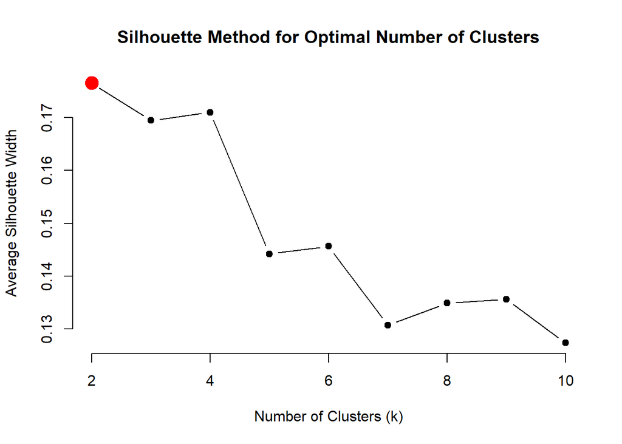

```r
# Plot silhouette width
plot(k_range, sil_widths, type = "b", pch = 19, frame = FALSE,
     xlab = "Number of Clusters (k)", ylab = "Average Silhouette Width",
     main = "Silhouette Method for Optimal Number of Clusters")

# Add a point for the optimal k
points(optimal_k_sil, sil_widths[optimal_k_sil - min(k_range) + 1], col = "red", cex = 2, pch = 19)
```

## after calculate the average silhouette width the best cluster was k=2